# PS 812

Section 9: Binned Scatterplots, Bias and Variance, and Confidence Intervals for the Line

John Hicks

Dept. of Political Science, UW-Madison

2026-11-06

# Today

## Today

**1. Binned scatterplots, again**

Cut, average, plot. Then overlay the regression line

**2. Bias and variance**

Lecture’s heuristic, measured: what do more bins cost, and what does the line cost?

**3. Confidence intervals for bins and for the line**

Error bars, the slope, and the band that `geom_smooth()` draws

**4. What the band doesn’t tell you**

A confidence interval measures variance. It knows nothing about bias

## Data

Back to the county returns from section 6:

```r
election <- read_csv("data/prez_election_2016_vote.csv") |>
  mutate(voteshare = 100 * candidatevotes / totalvotes) |>
  filter(!is.na(voteshare), !is.na(pctWhiteNH))

nrow(election)
```

```
[1] 3114
```

- One row per county: Clinton’s share of the vote and the % non-Hispanic white
- Same question as week 4: how does the average vote share change with $X$?

# Binned scatterplots: review

## Cut, average, plot

No two counties share a value of $X$, so we average **near** $x$ instead of **at** $x$. Wrap it in a function, since we’ll want many values of $k$:

```r
bin_means <- function(data, k) {
  data |>
    mutate(bin = ntile(pctWhiteNH, k)) |>         # k bins with equal counts
    group_by(bin) |>
    summarise(x_lo = min(pctWhiteNH), x_hi = max(pctWhiteNH),
              x = mean(pctWhiteNH), y = mean(voteshare), n = n())
}

binned <- bin_means(election, 20)
head(binned, 3)
```

```
# A tibble: 3 x 6
    bin  x_lo  x_hi     x     y     n
  <int> <dbl> <dbl> <dbl> <dbl> <int>
1     1  2.86  38.3  26.4  61.2   156
2     2 38.3   48.8  43.8  48.1   156
3     3 48.9   57.3  53.6  41.6   156
```

- One row per bin. This is its own data frame, so it’s its own `ggplot` layer

## The picture

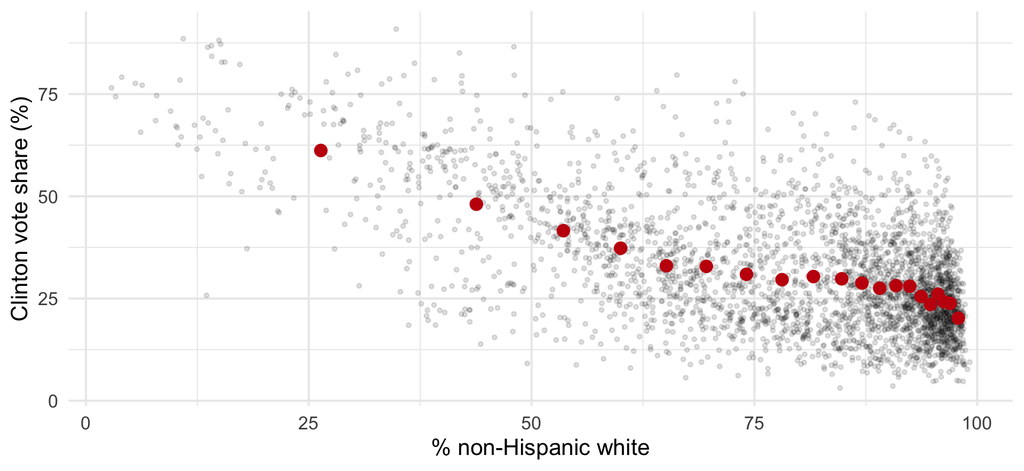

```r
ggplot(election, aes(x = pctWhiteNH, y = voteshare)) +
  geom_point(size = 1, alpha = 0.12) +
  geom_point(data = binned, aes(x = x, y = y), colour = uw_red, size = 3.5) +
  labs(x = lab_x, y = lab_y)
```

## Overlaying the line

We held off on `geom_smooth()` in section 6. Now we know what it fits:

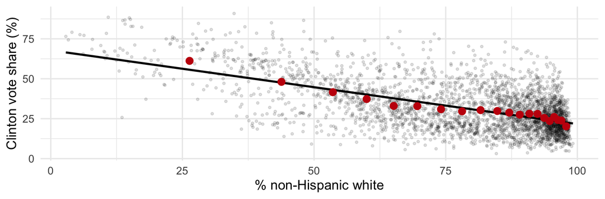

```r
ggplot(election, aes(x = pctWhiteNH, y = voteshare)) +
  geom_point(size = 1, alpha = 0.12) +
  geom_smooth(method = "lm", se = FALSE, colour = "black", linewidth = 1.2) +
  geom_point(data = binned, aes(x = x, y = y), colour = uw_red, size = 3.5) +
  labs(x = lab_x, y = lab_y)
```

- `method = "lm"`: OLS. `se = FALSE`: no band, for now

## It’s the same line three ways

From section 6, from lecture, and from `geom_smooth()`:

```r
beta_1 <- cov(election$pctWhiteNH, election$voteshare) / var(election$pctWhiteNH)
beta_0 <- mean(election$voteshare) - beta_1 * mean(election$pctWhiteNH)
ols_all <- lm(voteshare ~ pctWhiteNH, data = election)

rbind(by_hand = c(beta_0, beta_1), lm = coef(ols_all))
```

```
        (Intercept) pctWhiteNH
by_hand    67.80826 -0.4616726
lm         67.80826 -0.4616726
```

- $\hat\beta_1 = \widehat{\text{Cov}}(X, Y) / \widehat{\text{Var}}(X)$: the plug-in estimator of the best linear predictor
- Two very different estimators of the same relationship: 20 means, or 2 coefficients

## Where does the line miss?

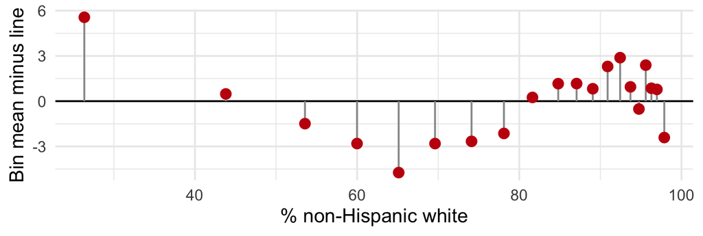

```r
binned |>
  mutate(gap = y - (beta_0 + beta_1 * x)) |>
  ggplot(aes(x = x, y = gap)) +
  geom_hline(yintercept = 0) +
  geom_segment(aes(xend = x, yend = 0), colour = "grey60") +
  geom_point(colour = uw_red, size = 3.5) +
  labs(x = lab_x, y = "Bin mean minus line")
```

- The line is a little **too low** at the left, **too high** around 50-75% white, and about right after that
- Not random: the misses have a **shape**. The CEF bends and the line can’t

# Bias and variance

## Bias-Variance Tradeoff

$$\text{MSE}(\hat\mu(x)) = \mathbb{E}\big[(\hat\mu(x) - \mu(x))^2\big] = \text{Bias}(\hat\mu(x))^2 + \text{Var}(\hat\mu(x))$$

- **Few, wide bins**: lots of counties per mean (low variance), but each mean averages over a region where $\mu(x)$ changes (bias)
- **Many, narrow bins**: little averaging over different $x$’s (low bias), but few counties per mean (high variance)
- **The line**: 2 numbers, and every county informs the fit at every $x$ (very low variance). But where $\mu(x)$ bends, it’s biased
- Today: put numbers on this. To measure bias, **we have to know the truth**

## A population we can check against

Treat the 3,114 counties as the **population**. Then the best linear predictor is known, and we can draw samples from it:

```r
ols_pop <- lm(voteshare ~ pctWhiteNH, data = election)      # m(x): the true BLP

# mu(x): a smooth stand-in for the true CEF, a local average over nearby counties
# (don't worry about this now)
cef_pop <- loess(voteshare ~ pctWhiteNH, data = election, span = 0.3, degree = 1)
election <- mutate(election, mu = fitted(cef_pop))

samp <- slice_sample(election, n = 300, replace = TRUE)     # one i.i.d. sample
```

- À la the ANES “population” in lecture last week
- With replacement, so every draw is i.i.d.
- No two counties share an $x$, so “the” population CEF needs some smoothing. We call this curve the truth

## The truth, and one sample

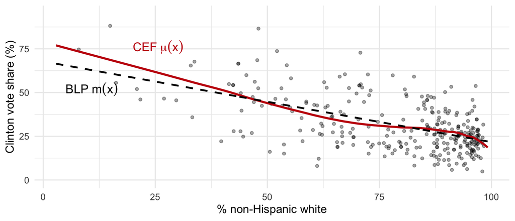

- We never see these two curves in practice. We see the grey points

## Three estimators, one sample

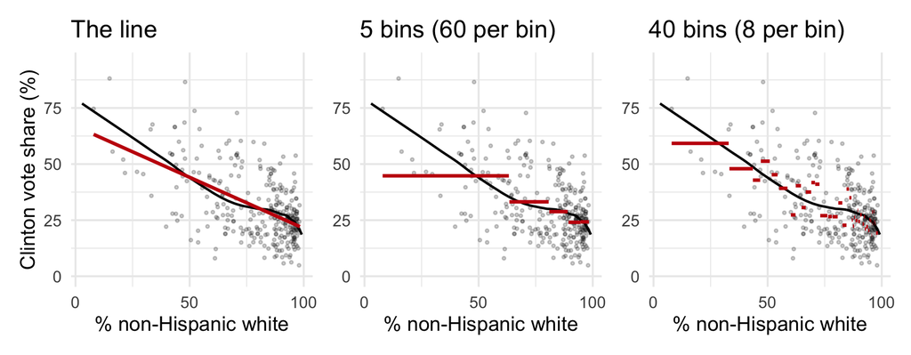

- Black: the truth. Red: the estimate from this one sample
- Which is best? We can’t tell from one sample. Bias and variance are about **repeated** samples

## Writing the estimators down

Each one takes a sample and returns its estimate of the CEF at the points `at`:

```r
fit_bins <- function(s, k, at) {
  b <- bin_means(s, k)
  # return the mean of the bin each point in `at` falls into
}

fit_line <- function(s, at) {
  b <- coef(lm(voteshare ~ pctWhiteNH, data = s))
  b[[1]] + b[[2]] * at
}
```

- No model for the bins: just a step function through the bin means
- Same function signature for both, so we can hand either one to a simulation

## 100 samples of 300 counties

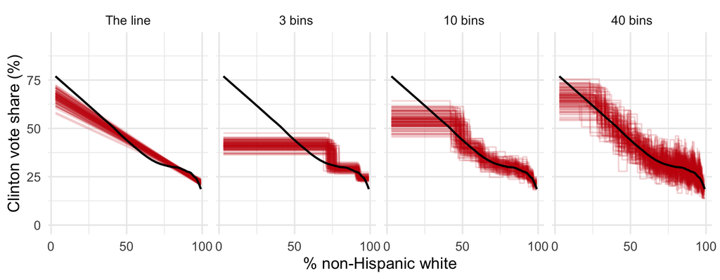

- **Bias**: does the red cloud sit on the black curve? **Variance**: how wide is the cloud?
- The line and 3 bins are tight but off. 40 bins is on target but all over the place

## Now the numbers

Average over the counties in the population:

```r
score <- function(estimator, n, reps = 300) {
  fits <- replicate(reps, {
    s <- slice_sample(election, n = n, replace = TRUE)
    estimator(s, election$pctWhiteNH)                # one column per sample
  })
  tibble(n = n,
         bias2    = mean((rowMeans(fits) - election$mu)^2),
         variance = mean(apply(fits, 1, var)),
         mse      = bias2 + variance)
}
```

- Run it for the line and for $k$ from 2 to 50, at $n = 300$ and $n = 3{,}000$
- Bias$^2$ and variance at each county’s $x$, then averaged. Counties count equally, so the dense right side counts more
- Bias$^2$ bottoms out above zero at large $k$, because our “truth” is a smooth stand-in, not the exact local averages

## The tradeoff, $n = 300$

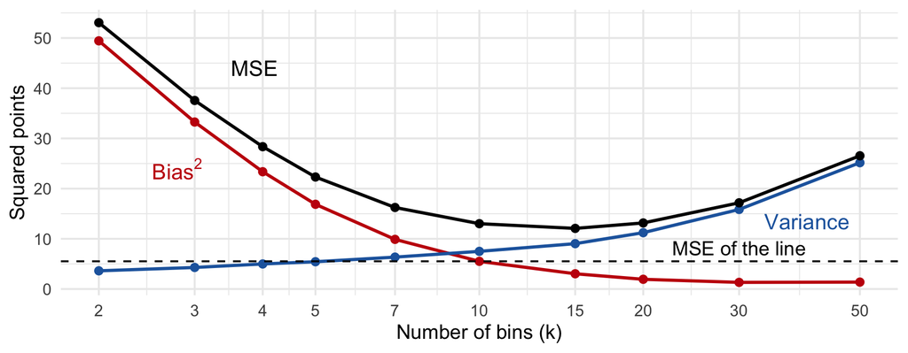

- More bins: bias falls, variance rises. Best at about $k =$ 15, with MSE 12.1
- The line is **wrong** (bias$^2$ 4.4) but still beats every $k$ (MSE 5.5). Being stable can be worth more than being right

## More data moves the answer

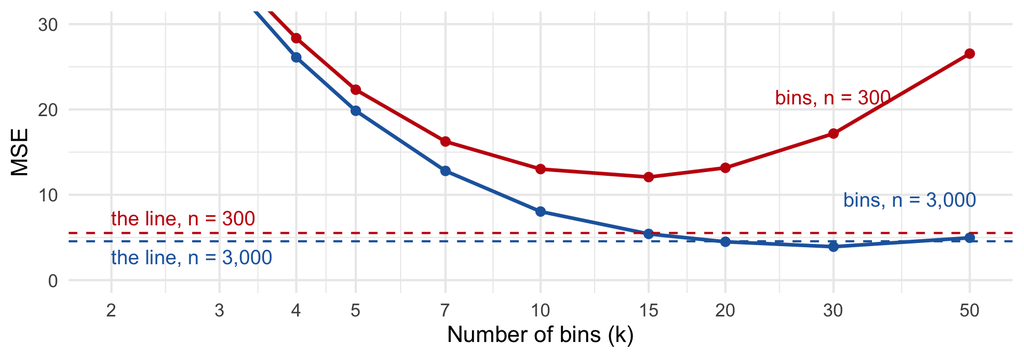

- With more data, variance shrinks for everything, but the line’s bias **stays**. Best $k$ rises to about 30, and now bins beat the line (MSE 3.9 vs. 4.6)
- So $k$ should grow with $n$, like the histogram bins in week 7.

# Confidence intervals

## From many samples to one

- We just saw the sampling variation because we had the whole population
- In practice we have **one** sample. Same logic as week 8: estimate the $SE$, then

$$\text{estimate} \pm 1.96 \times \widehat{SE}$$

- So what are the estimates? Three of them, in order:
  1. A **bin mean**
  2. The **slope**
  3. The **line at $x$**, $\hat\beta_0 + \hat\beta_1 x$
- From here on, `samp` plays the part of our data: 300 counties

## A bin mean is just a mean

So we already know its SE, $s_b / \sqrt{n_b}$:

```r
bin_ci <- function(data, k) {
  data |>
    mutate(bin = ntile(pctWhiteNH, k)) |>
    group_by(bin) |>
    summarise(x = mean(pctWhiteNH), y = mean(voteshare), n = n(),
              se = sd(voteshare) / sqrt(n)) |>
    mutate(lower = y - qnorm(0.975) * se, upper = y + qnorm(0.975) * se)
}

bins_10 <- bin_ci(samp, 10)
bins_10 |> head(3)
```

```
# A tibble: 3 x 7
    bin     x     y     n    se lower upper
  <int> <dbl> <dbl> <int> <dbl> <dbl> <dbl>
1     1  37.9  51.7    30  3.10  45.6  57.8
2     2  57.5  37.8    30  2.88  32.2  43.5
3     3  67.6  37.6    30  2.68  32.4  42.9
```

- Same as any CI for a mean from week 8, one bin at a time

## Error bars with `geom_errorbar()`

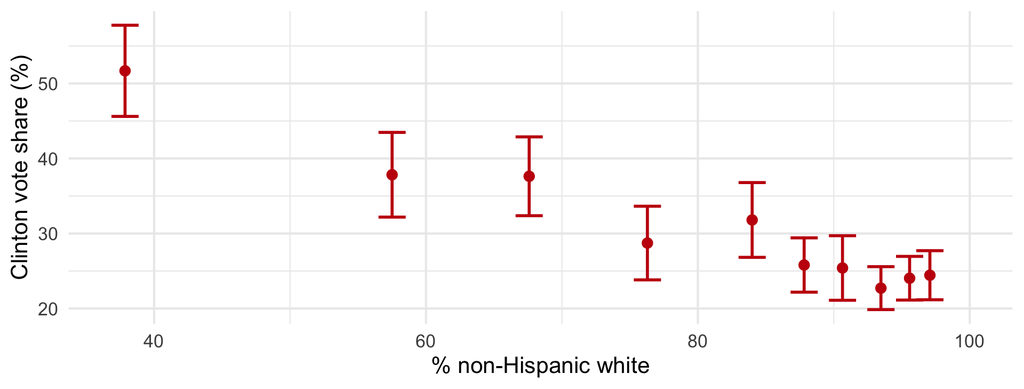

```r
ggplot(bins_10, aes(x = x, y = y, ymin = lower, ymax = upper)) +
  geom_errorbar(colour = uw_red, width = 2, linewidth = 1) +
  geom_point(colour = uw_red, size = 2.8) +
  expand_limits(x = 100) +
  labs(x = lab_x, y = lab_y)
```

- `geom_errorbar()` needs `x`, `ymin`, `ymax`, and `geom_point()` adds `y`. Same four numbers as the table

## More bins, wider intervals

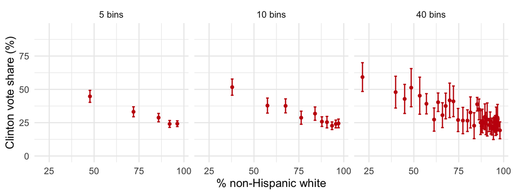

- The price of flexibility, now visible in one sample. Go from 5 to 40 bins and $n_b$ falls 8-fold, so intervals are $\sqrt 8 \approx 2.8$ times wider
- With 40 bins, only 7 or 8 counties per bin. Use $t$ critical values there (week 8), or don’t use 40 bins

## Bins are a regression too

Regress $Y$ on a set of bin dummies, with no intercept. OLS returns the bin means:

```r
samp_b <- mutate(samp, bin = factor(ntile(pctWhiteNH, 10)))
fit_bin <- lm(voteshare ~ 0 + bin, data = samp_b)

tibble(by_hand_mean = bins_10$y, ols_coef = coef(fit_bin)) |>
  head(3)
```

```
# A tibble: 3 x 2
  by_hand_mean ols_coef
         <dbl>    <dbl>
1         51.7     51.7
2         37.8     37.8
3         37.6     37.6
```

- So a binned scatterplot and a line are both OLS. They differ in **how many coefficients** we spend on $X$

## A confidence interval for the slope

```r
x <- samp$pctWhiteNH
y <- samp$voteshare
n <- nrow(samp)

beta_1 <- cov(x, y) / var(x)
beta_0 <- mean(y) - beta_1 * mean(x)
e <- y - (beta_0 + beta_1 * x)                 # residuals

sigma2 <- sum(e^2) / (n - 2)                   # residual variance
var_1  <- sigma2 / sum((x - mean(x))^2)
se_1   <- sqrt(var_1)

lower_1 <- beta_1 - qnorm(0.975) * se_1
upper_1 <- beta_1 + qnorm(0.975) * se_1
c(estimate = beta_1, se = se_1, lower = lower_1, upper = upper_1)
```

```
   estimate          se       lower       upper
-0.45472297  0.03867667 -0.53052785 -0.37891808
```

- Bigger residuals mean a bigger SE. A wider spread of $X$ means a smaller one. Lecture covers why next week

## Reading the interval

- A one-point increase in % white is associated with a change in Clinton’s vote share of between -0.53 and -0.38 points, on average
- In this example we know the population slope, $\beta_1 =$ -0.46. This interval happens to contain it
- Careful: a CI needs a sampling thought experiment. Fit this to **all** 3,114 counties and we’d have to imagine them as draws from something larger

## Does it work? 100 samples

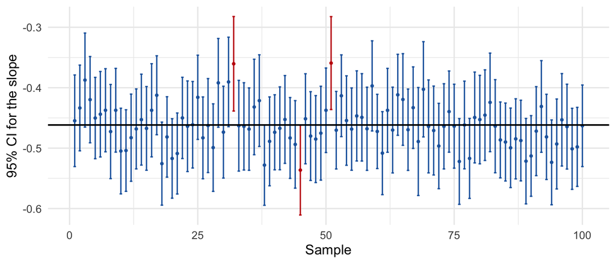

- Over 2,000 samples of 300, the interval covers $\beta_1$ 92.3% of the time. A bit short of 95%, because these SEs assume the same noise at every $x$, and counties are noisier on the left
- This is the ring toss from lecture: the truth (black) stays put, the intervals move

## From the slope to the line

At any $x$, the fitted line is a sum of two estimates:

$$\hat m(x) = \hat\beta_0 + \hat\beta_1 x$$

so its variance is the variance of a sum, with $x$ as a constant:

$$\widehat{\text{Var}}\big(\hat m(x)\big) = \widehat{\text{Var}}(\hat\beta_0) + x^2 \, \widehat{\text{Var}}(\hat\beta_1) + 2x \, \widehat{\text{Cov}}(\hat\beta_0, \hat\beta_1)$$

- Same rule as the difference in means in week 8, but now the **covariance term doesn’t vanish**: the two coefficients come from the same data

## The band, by hand

We have `var_1`. Add the other two pieces, compute the interval at a grid of $x$’s, then draw it with `geom_ribbon()`:

```r
var_0  <- sigma2 * (1 / n + mean(x)^2 / sum((x - mean(x))^2))
cov_01 <- -mean(x) * var_1

band <- tibble(pctWhiteNH = seq(min(samp$pctWhiteNH), max(samp$pctWhiteNH), length.out = 200)) |>
  mutate(fit   = beta_0 + beta_1 * pctWhiteNH,
         se    = sqrt(var_0 + pctWhiteNH^2 * var_1 + 2 * pctWhiteNH * cov_01),
         lower = fit - qnorm(0.975) * se,
         upper = fit + qnorm(0.975) * se)
```

- `se` depends on `pctWhiteNH`, so the interval has a different width at every $x$
- `lower` and `upper` are the columns `geom_ribbon()` will want

## The band, drawn

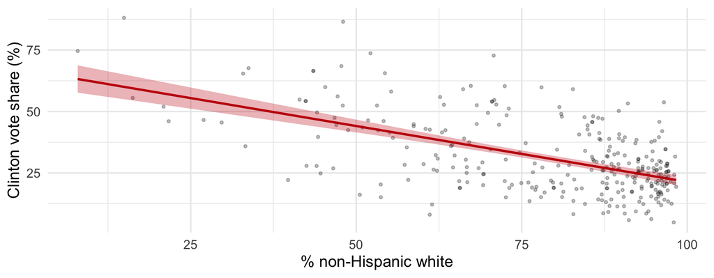

```r
ggplot(band, aes(x = pctWhiteNH)) +
  geom_point(data = samp, aes(y = voteshare), size = 1, alpha = 0.25) +
  geom_ribbon(aes(ymin = lower, ymax = upper), fill = uw_red, alpha = 0.3) +
  geom_line(aes(y = fit), colour = uw_red, linewidth = 1.1) +
  labs(x = lab_x, y = lab_y)
```

## Why is it a bow tie?

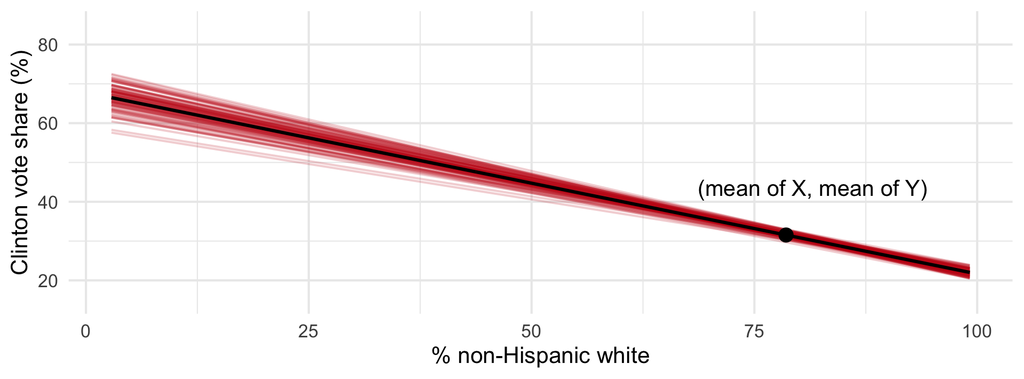

- Every OLS line passes through $(\bar X, \bar Y)$. Samples move that point a little and tilt the line around it
- So the band is **narrowest near** $\bar X$ and fans out toward the edges, especially the sparse left end. Here $\bar X =$ 79, and the SE runs from 0.72 to 2.83

## The shortcuts

```r
fit <- lm(voteshare ~ pctWhiteNH, data = samp)
predict(fit, newdata = band, se.fit = TRUE)   # 1. the same SEs as our formula
geom_smooth(method = "lm", se = TRUE)         # 2. draws a band for you
```

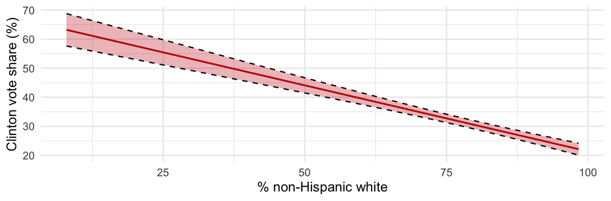

- Red: our band. Dashed: `predict()` and `geom_smooth()`. Same SEs, so they sit right on top of it

## Observations are still missed!

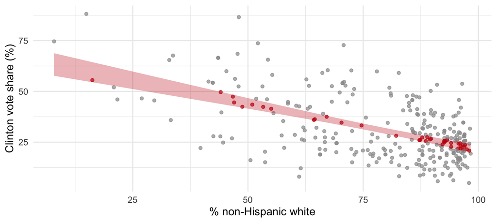

## Coverage at each $x$ and for the whole line

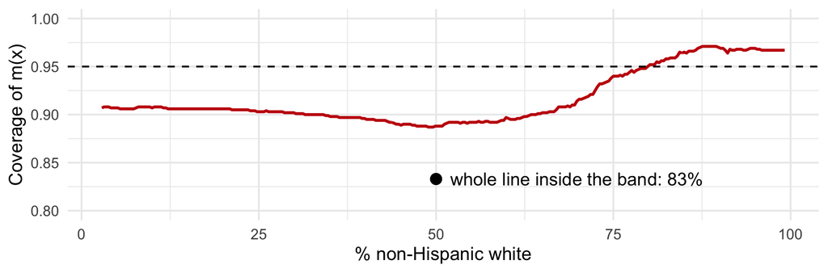

- At **each** $x$, the band covers $m(x)$ between 89% and 97% of the time (red). Off from 95% because of that same noise assumption
- But the **whole** true line sits inside in only 83% of samples: more than one $x$ gives more chances to miss. A band for the whole line needs about $\pm$ 2.63 SEs here, wider than $\pm$ 1.96

# What the band doesn’t tell you

## All 3,114 counties

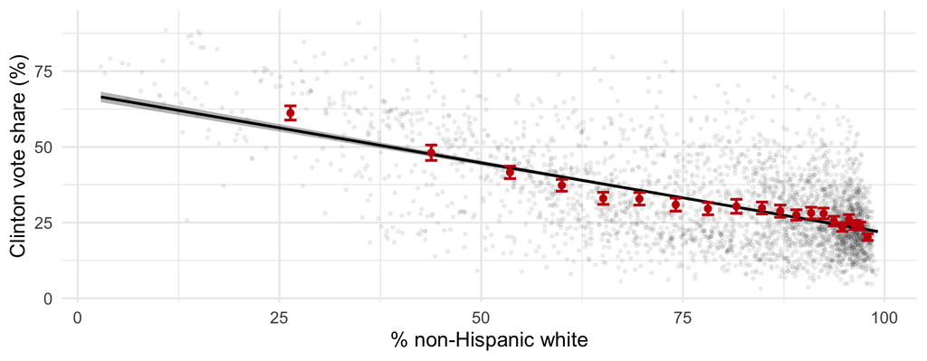

- A very tight band around the line. And 8 of the 20 bin-mean intervals don’t overlap it
- Both are 95% intervals. They’re answering **different questions**

## Spending another coefficient

`geom_smooth()` can fit any formula, so a quadratic is one argument away:

```r
geom_smooth(method = "lm", formula = y ~ poly(x, 2))
```

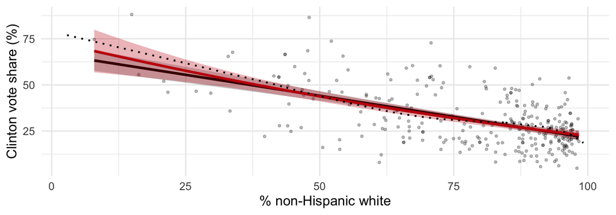

- Black: the line. Red: the quadratic. Dotted: the truth. Red tracks it better but is wider where data are sparse: MSE 3.2 vs. 5.5 for the line
- Line, quadratic, bins: one tradeoff. More coefficients, less bias, more variance

## Which plot should you show?

Binned means and the line **together**, each with its uncertainty:

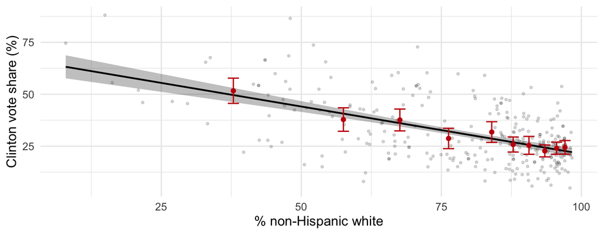

- The **line** is one precise summary, and its band says how sure we are of **that** summary
- The **bins** check whether the summary is any good. Report a slope with no bins, and the reader can’t tell

## Recap

- **Binned scatterplots** estimate the CEF with no shape assumption. `geom_smooth(method = "lm")` adds the BLP on top
- **Bias vs. variance**: more bins lowers bias and raises variance. The line is the low-variance extreme, and with small $n$ it can win even though it’s wrong
- **More data**: variance falls, bias doesn’t. So use more bins as $n$ grows
- **CIs**: a bin mean is a mean. The line at $x$ is a sum of two estimates, so include the covariance
- **The band** is a bow tie, is for the **average** at $x$, and holds at each $x$, not all at once
- **CIs measure variance only**. The band covers the BLP, and it can miss the CEF

# Exercise

## Exercise

Open `ps812_section9_exercise.qmd`. We switch to the hostile sexism data from lecture.

- Part 1: binned scatterplots and the line
- Part 2: bias and variance, by simulation
- Part 3: confidence intervals for bins and the line